# Criminalità Informatica

A Cura Di

Giulio Sanna

# Hacker o Cracker?

**Hacker** è il nome che spesso viene dato a quelle entità criminose che sfruttano l’informatica per un benessere personale, in realtà gli *Hacker* sono degli appasionati dell’informatica che spesso si ritrovano a violare sistemi di sicurezza per scopo quasi del tutto accademico, molti di questi, infatti aiutano i proprietari di tali sistemi a renderli più sicuri.

Tuttavia in quella che oggi è una vera e propria cultura etica Hacker, questi ultimi sono concettualmente divisi in tre categorie White Hat, Grey Hat, Black Hat, queste 3 suddivisioni dovrebbero raffigurare la *“nobiltà”* delle azione di un hacker.

**Cracker** o pirata informatico è colui che spezza e danneggia sistemi di sicurezza per un tornaconto personale (spionaggio industriale, frodi, estorsioni…), un cracker spesso utilizza tecnologie di *port-scanning* per individuare vulnerabilità in una macchina e tramite queste può accedere a console remote per effetuare uno scalo di privilegi ottenendo lo status di **Root**.

Lo status di **Root** si rivela essenziale per nascondere le proprie tracce, fare sniffing di dati in transito, o addirittura modificare il `Kernel` per dirottarne le System Call.

# Obiettivi Più Colpiti Del Primo Anno

Nel 2018 abbiamo una situazione che rispecchia le ipotesi immaginate, ovvero al primo posto troviamo gli elementi più vulnerabili, meno protetti e spesso ignoranti in materia di sicurezza, e quindi facilmente vittime di attacchi contingenti quali phishing, Virus, Mitm, ecc…

Al giorno d’oggi le aziende informatiche investono molto sullo sviluppo di **Firewall** e **Antivirus**, tuttavia sono i consumatori che in primo luogo dovrebbero tutelare i propri sistemi con semplici accorgimenti che spesso vengono ignorati. Questa tendenza a trascurare le più semplici contro misure comporta un aumento sempre crescente degli attacchi, si stima che il costo globale del **Crimine Informatico** sia radoppiato negli ultimi 7 anni e ad oggi si aggiri sui 10 trilioni di dollari all’anno (10<sup>18</sup>), gli attacchi effettuati invece si sono quintuplicati negli ultimi 7 anni.

*Source:* Privacy GDPR

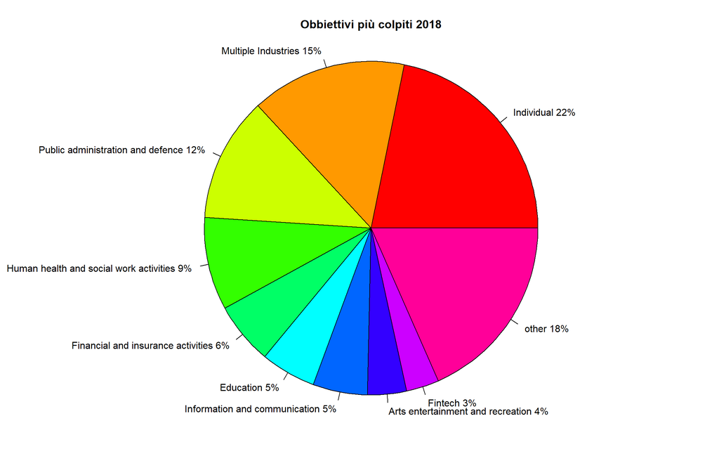

# Obiettivi più colpiti Del Secondo Anno

Nel 2020 notiamo un interessante diminuzione del 10% degli attacchi recati ai singoli individui ma anche un aumento del 4% sulle industrie, probabilmente dovuto al fatto che nel 2020 molte aziende si sono interfacciate con lo **Smart Working**, molte utilizzando metodologie dubbiose o piataforme poco sicure.

*Basti ricordare che in aprile 2020, ci sono stati più 500 mila furti di account Zoom, i quali sono stati poi rivenduti nel Dark Web, questo fu l’inizio di molti attacchi diretti a queste nuove piattaforme che si sono ritrovate ad avere in pochissimo tempo millioni di nuovi uteti*

*Source:* [La Repubblica](https://www.repubblica.it/tecnologia/sicurezza/2020/04/19/news/videchat_zoom_ancora_sotto_attacco_oltre_500_mila_credenziali_finiscono_sul_dark_web-254477620/)

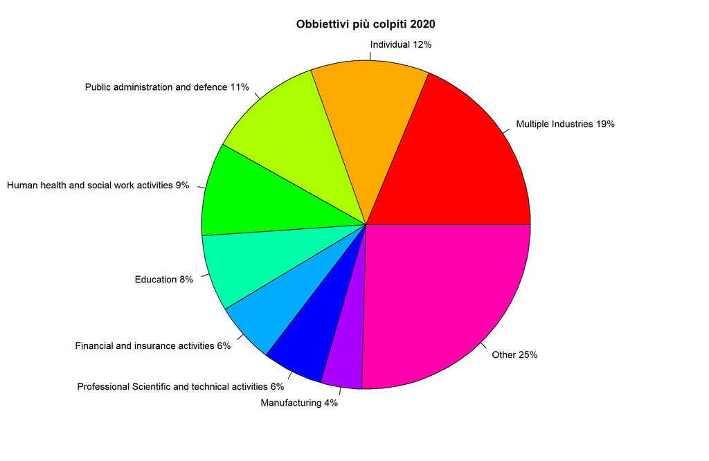

# Obiettivi più colpiti Del Terzo Anno

Nel 2021 notiamo un continuo aumentare delle industrie ed un leggero calo agli individui, tuttavia anche un interessante **aumento del 3%** di attacchi effettuati contro la **Sanità**, questo aumento potrebbe essere corelato alla campagna vaccinale, la quale è stata fortemente contrastata, sia dalla disinformazione che da effettivi attacchi informatici.

É importante ricordare di come la campagna vaccinale della regione Lazio ha avuto uno stop in concomitanza con l’uscita delle 2°Dosi, per via di un **trojan cryptolocker**.  
Il **Trojan Cryptolocker** è un **`Ransomware`** ovvero un *Malware* che limita l’accesso dei dati (nello specifico del Cryptolocker, criptandoli), spesso bloccando il sistema e intimando l’utente a pagare per lo sblocco e la decriptazione dei dati, in questo specifico caso era stato richiesto un pagamento in **Bitcoin**, dell’equivalente di 5 millioni di euro.

*Source:* [La Repubblica](https://roma.repubblica.it/cronaca/2021/08/01/news/covid_attacco_hacker_al_lazio_disattivati_sistemi_e_portale_della_rete_vaccinale-312554980/) *,*[Fanpage](https://www.fanpage.it/roma/quanto-hanno-chiesto-di-riscatto-gli-hacker-alla-regione-lazio/)

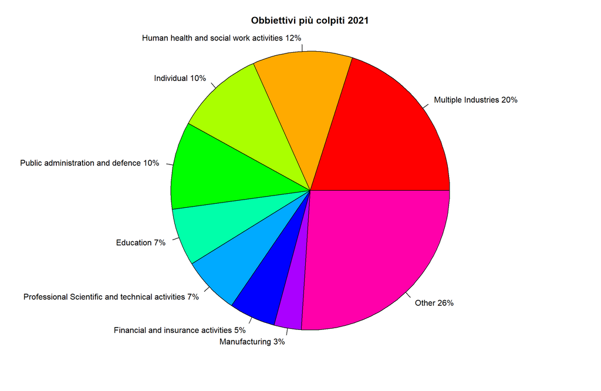

# Andamento Degli Attacchi

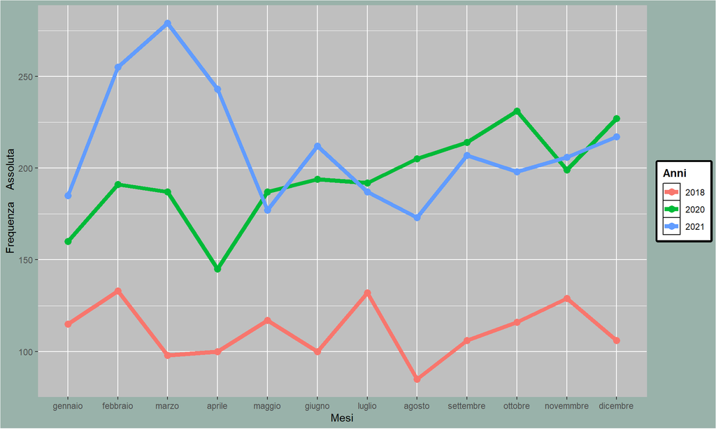

# Classe Degli Attacchi

- *CC:*Cyber Crime consiste in una attività criminosa, analoga a quella tradizionale ma caratterizzata dall’abuso di componenti della tecnologia dell’informazione (sia hardware che software).
- *CE:* Cyber Espionage rappresenta una delle più importanti minacce dirette verso le aziende ed il settore pubblico. La sottrazione di know-how tecnologico, nonché di informazioni riservate.
- *CW:*Cyber War si verifica mediante l’uso di attacchi informatici contro uno stato nemico o organizzazione, che causano danni paragonabili ad una guerra reale.
- *HK:*Hacktivismo si verifica quando attivisti politici o sociali utilizzano la tecnologia informatica per fare una dichiarazione a sostegno di una delle loro cause.

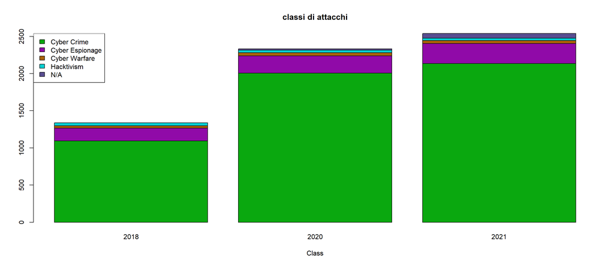

# Paesi Maggiormente Bersagliati

La mappa sotto riportata rappresenta i paesi con la maggior frequenza d’attacchi subiti nel corso di questi tre anni.  
Vediamo subito che gli Stati Uniti sono al primo posto, tuttavia bisogna fare alcune considerazioni sulla correttezza della mappa:

1. I casi presenti nei nostri Dataset, sono casi che hanno avuto una certa rilevanza mediatica, per ognuno di essi infatti esiste un articolo in almeno una testata giornalistica nazionale, quindi la scelta dei dati presenti nel campione statistico non è una scelta aleatoria. Di conseguenza le informazioni ricavabili dalla mappa devono essere solo indicative e veritiere solo parzialmente.
2. I dati utilizzati per questa ricerca provengono da un sito il cui proprietario è italiano, quindi avrà avuto accesso a più materiale italiano.[**<sub>(Hackmageddon)</sub>**](https://www.hackmageddon.com/)
3. Bisogna rammentare che non tutti gli stati sovrani sono dotati della stessa sincerità, un regime difficilmente rivelerà una propria inefficienza in temi di sicurezza. Ma non solo, neanche per i paesi più democratici non conviene divulgare certe informazioni, di conseguenza bisogna partire dal presupposto che la maggiorparte degli attacchi di Cyber Warfare sono occultati da attività di *Intelligence* e prima di una loro divulgazione c’è sicuramente una profonda analisi da parte dei servizi segreti. Questo spiega anomalie come quella della **Nord Corea**.

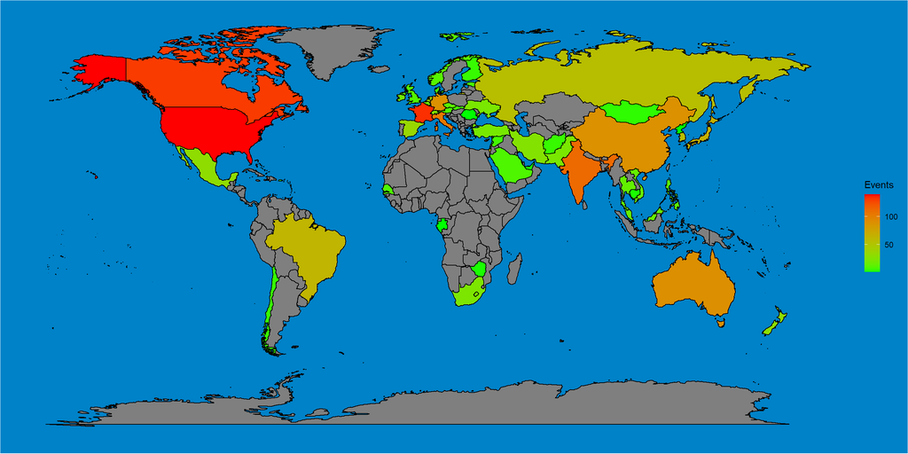

# Stati Sovrani Come Cyber Terroristi?

##### “-The Incredible Rise of North Korea’s Hacking Army”*[**(New Yorker)**](https://www.newyorker.com/magazine/2021/04/26/the-incredible-rise-of-north-koreas-hacking-army)*

La Nord Corea è uno dei paesi più attivi dal punto di vista del **Terrorismo Informatico** a tal punto che la stessa **FBI**, **CISA***(Cybersecurity and Infrastructure Security Agency)* ed il **Dipartimento Del Tesoro Degli Stati Uniti** hanno proferito a riguardo, affermando che la Nord Corea è coinvolta in moltissimi attacchi ai danni di infrastrutture sanitarie americane, ed altre società che fanno un utilizzo importante delle **Crypto Currency**.

Nell’Aprile 2022, due gruppi “Hacker” chiamati *Lazarus* e *APT38*, affiliati con i servizi segreti Nord Coreani sono responsabili per un furto di circa 620 millioni di dollari in **Ethereum** ai danni dell’azienda “*Sky Mavis*”.  
La Nord Corea spesso trafuga delle **Cripto Valute** per bypassare le sanzioni in vigore anche per finanziare gravose spese, come quella militare

Tuttavia non solo la Nord Corea presenta un pericolo in tal senso, in passato anche il governo **Statunitense** e **Israeliano** sono stati fautori di pericolosissimi attacchi tramite la creazione di minacciosi malware come ([**Stuntex**](https://www.safetysecuritymagazine.com/articoli/stati-e-guerre-senza-confini-geografici/) e **Pegasus**)

*Source:* [New Yorker](https://www.newyorker.com/magazine/2021/04/26/the-incredible-rise-of-north-koreas-hacking-army), [Tag43](https://www.tag43.it/indagine-fbi-hacker-nord-corea-furto-criptovalute-sky-mavis-societa-videogiochi/), [Wired](https://www.wired.it/internet/web/2018/05/30/corea-nord-hacking/), TechCrunch, [La Repubblica](https://www.repubblica.it/esteri/2022/02/06/news/corea_del_nord_arsenale_nucleare_rapporto_onu-336693992/)  
*Source:* [Safety&Security](https://www.safetysecuritymagazine.com/articoli/stati-e-guerre-senza-confini-geografici/), Wikipedia, [La Repubblica](https://www.repubblica.it/esteri/2022/07/29/news/pegasus_predator_spyware_per_spiare_cellulari_ue_eurodeputati_commissione-359628643/)

# Metodologie Più Utilizzate

- **Unknown:** “Unknown” ovvero metodologia sconosciuta, questo sicuramente è esplicativo di come alcuni attacchi possano essere distruttivi ed allo stesso tempo estremamente occultat.i
- **POS Malware:**Il “*Point of Sale* Malware è uno script malevolo creato per ottenere le informazioni delle carte di credito, di solito questo attacco viene realizzato tramite molteplici attacchi Mitm.
- **Account Hijacking:**L’account Hijacking è un tipo particolare di *furto d’identità*, vale a dire processo attraverso il quale è possibile ottenere l’accesso ad un account email o ad un account di un computer, con relativi account associati.
- **Vulnerability:**Le vulnerabilità sono diffetti di fabbrica, le quali vengono sfruttate per compiere degli illeciti, è importate aggiornare spesso dei sistemi poiché ogniqualvolta la casa costruttrice trova una *Vulnerabilità* la patcha e la rende pubblica, in questo modo molti Hacker hanno avuto metà del lavoro svolto.
- **Malware:**Malware o “software malevolo” è un termine generico che descrive un programma/codice dannoso che mette a rischio un sistema.
- **DDoS:**Un attacco DDoS consiste nell’inondare un sito web di richieste in un breve periodo di tempo, con l’obiettivo di travolgere il sito e causarne il crash. Il termine “distribuito” significa che questi attacchi provengono da più luoghi contemporaneamente, rispetto a un DoS che proviene da un solo luogo.
- **Malicious Code Injection:**L’iniezione di codice è lo sfruttamento di un bug del computer causato dall’elaborazione di dati non validi. L’iniezione viene utilizzata da un utente malintenzionato per introdurre codice in un programma per computer vulnerabile e modificare il corso dell’esecuzione.
- **Defacement:**nell’ambito della sicurezza informatica ha solitamente il significato di cambiare illecitamente la home page di un sito web (la sua “*faccia*”) o modificarne, sostituendole, una o più pagine interne.
- **Bots:**Un social bot posta i propri contenuti per lo più tramite account fasulli dotati di una foto profilo, post precedenti e spesso addirittura follower e amici. Attraverso questi account il bot diffonde i suoi messaggi, che siano di marketing o che abbiano finalità politiche.
- **SQL Injection:**Nella sicurezza informatica **SQL** injection è una tecnica di code injection, usata per attaccare applicazioni che gestiscono dati attraverso database relazionali sfruttando il linguaggio SQL. Il mancato controllo dell’input dell’utente permette di inserire artificiosamente delle stringhe di codice SQL che saranno eseguite dall’applicazione server: grazie a questo meccanismo è possibile far eseguire comandi SQL, anche molto complessi, dall’alterazione dei dati (es. creazione di nuovi utenti) al download completo dei contenuti nel database.

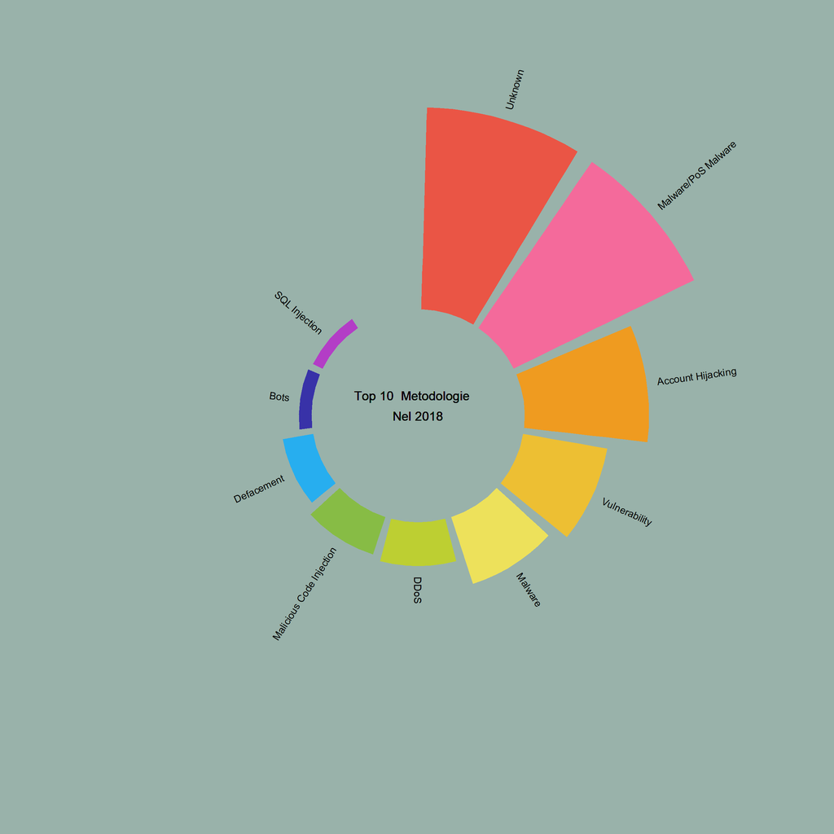

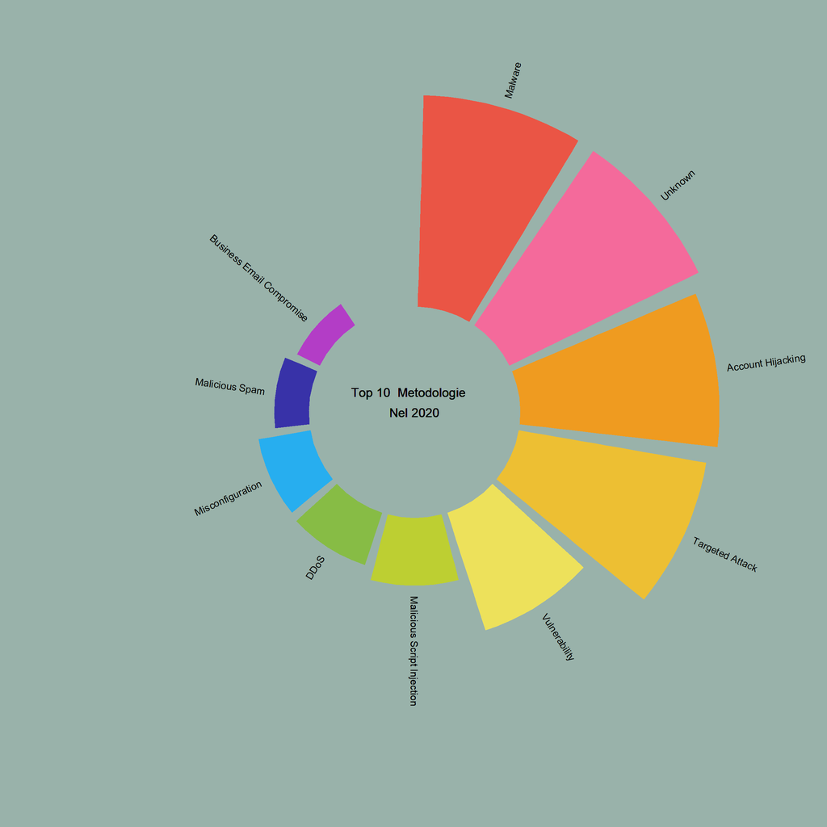

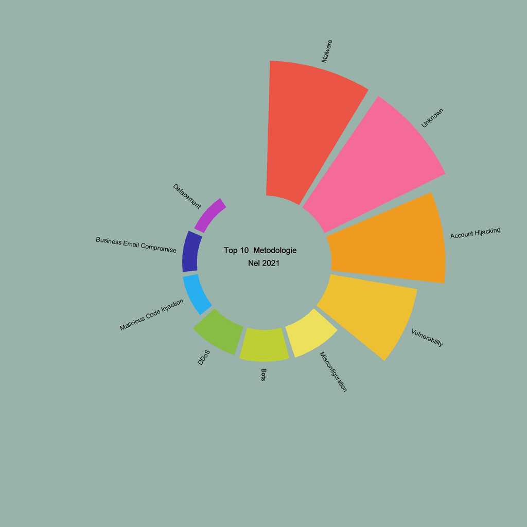

# Passwords

#### Concludendo il discorso sui “Semplici Accorgimenti Che Tendono Ad Essere Ignorati”, trovo importate citare una particolare forma di attacco,ovvero quella a dizionario.

In antitesi con un metodo forza bruta, dove tutte le possibili password sono ricercate in maniera esaustiva, un attacco a dizionario prova solamente quelle ritenute più probabili, tipicamente contenute in una lista . Generalmente, questi attacchi, hanno successo perché la maggior parte delle persone ha la tendenza a scegliere password semplici da ricordare (e quindi semplici da scoprire, ad esempio il proprio nome, quello dei propri figli, date di nascita) e tendenzialmente sceglie parole prese dalla propria lingua nativa.  
Poiché di solito gli utenti scelgono password facilmente indovinabili, questo attacco ha successo in media 4 volte su 10 quando si utilizza una lista di parole ragionevolmente grande.

### Le 500 Password più utilizzate

[interactive chart not shown]

*Source:* [GitHub](https://raw.githubusercontent.com/rfordatascience/tidytuesday/master/data/2020/2020-01-14/passwords.csv)

# Grazie Per L’Attenzione!

- Costo Degli attacchi informatici all’anno
- [I 500 Mila Account Rubati Di Zoom](https://www.repubblica.it/tecnologia/sicurezza/2020/04/19/news/videchat_zoom_ancora_sotto_attacco_oltre_500_mila_credenziali_finiscono_sul_dark_web-254477620/)
- [Attacco Hacker Al Lazio](https://roma.repubblica.it/cronaca/2021/08/01/news/covid_attacco_hacker_al_lazio_disattivati_sistemi_e_portale_della_rete_vaccinale-312554980/)
- [Riscatto Al Lazio](https://www.fanpage.it/roma/quanto-hanno-chiesto-di-riscatto-gli-hacker-alla-regione-lazio/)
- L’“Armata” Degli Hacker Nord Coreani
- [Furto A Sky Mavis](https://www.tag43.it/indagine-fbi-hacker-nord-corea-furto-criptovalute-sky-mavis-societa-videogiochi/)
- Sanità Americana Sotto Attacco Dalla Nord Corea
- [Finanziamento Nucleare Nord Coreano Tramite Le Cripto](https://www.repubblica.it/esteri/2022/02/06/news/corea_del_nord_arsenale_nucleare_rapporto_onu-336693992/)
- [Chi Sono Gli Hacker Nord Coreani](https://www.wired.it/internet/web/2018/05/30/corea-nord-hacking/)
- [Datasets 2018,2020,2021](https://www.hackmageddon.com/)
- [Stuntex Malware](https://www.safetysecuritymagazine.com/articoli/stati-e-guerre-senza-confini-geografici/)
- Pegasus Malware
- [Top 500](https://raw.githubusercontent.com/rfordatascience/tidytuesday/master/data/2020/2020-01-14/passwords.csv)